# The Kira Plastinina Brand.

An Unsupervised Learning Approach in Clustering

Joseph Kirika

08/07/2021

## Defining the Question

### a) Specifying the Question

- To learn the characteristics of customer groups.

### b) Defining the Metric for Success

Perform clustering stating insights drawn from your analysis and visualizations.  
Upon implementation, provide comparisons between K-Means clustering vs Hierarchical clustering highlighting the strengths and limitations of each approach in the context of the analysis.

### c) Understanding the context

Kira Plastinina (Russian: Ки́ра Серге́евна Пласти́нина) is a Russian fashion designer and entrepreneur. Her brand was sold through a now defunct chain of eponymous retail stores in Russia, Ukraine, Kazakhstan, Belarus, China, Philippines and Armenia.We are required to understand the brand customer’s behavior from data they collected over an year.

### d) Recording the Experimental Design

- Reading the dataset
- Cleanig and dealing with anomalies to ensure that the quality of the data is upto the task
- Exploring the given dataset using univariate and bivariate techniques
- Highlighting the insights given
- Implementing the solution through K means and Hierarchical clustering
- Attempting to challenge the solutions given
- Providing some conclusions and recommendations

### e) Data Relevance

The data relevance ought to be evaluated against the metric of success after analysis.The dataset consists of 10 numerical and 8 categorical attributes.  
The following is a list of variable names describing the dataset given:

- The **‘Revenue’** attribute can be used as the class label.
- **“Administrative”**, **“Administrative Duration”**, **“Informational”**, **“Informational Duration”**, **“Product Related”** and **“Product Related Duration”** represents the number of different types of pages visited by the visitor in that session and total time spent in each of these page categories. The values of these features are derived from the URL information of the pages visited by the user and updated in real-time when a user takes an action, e.g. moving from one page to another.
- The **“Bounce Rate”**, **“Exit Rate”** and **“Page Value”** features represent the metrics measured by “Google Analytics” for each page in the e-commerce site. The value of the **“Bounce Rate”** feature for a web page refers to the percentage of visitors who enter the site from that page and then leave (“bounce”) without triggering any other requests to the analytics server during that session. The value of the **“Exit Rate”** feature for a specific web page is calculated as for all pageviews to the page, the percentage that was the last in the session.The **“Page Value”** feature represents the average value for a web page that a user visited before completing an e-commerce transaction.
- The **“Special Day”** feature indicates the closeness of the site visiting time to a specific special day (e.g. Mother’s Day, Valentine’s Day) in which the sessions are more likely to be finalized with the transaction. The value of this attribute is determined by considering the dynamics of e-commerce such as the duration between the order date and delivery date. For example, for Valentina’s day, this value takes a nonzero value between February 2 and February 12, zero before and after this date unless it is close to another special day, and its maximum value of 1 on February 8.
- The dataset also includes the **operating system**, **browser**, **region**, **traffic type**, **visitor type** as returning or new visitor, a Boolean value indicating whether the date of the visit is **weekend**, and **month** of the year.

## Importing And Previewing The Data

### Importing the data

```r
# importing the data
df<-read.csv("http://bit.ly/EcommerceCustomersDataset")
```

### Previewing the data

```r
#checking the top rows of our dataset
print(head(df))
```

```
##   Administrative Administrative_Duration Informational Informational_Duration
## 1              0                       0             0                      0
## 2              0                       0             0                      0
## 3              0                      -1             0                     -1
## 4              0                       0             0                      0
## 5              0                       0             0                      0
## 6              0                       0             0                      0
##   ProductRelated ProductRelated_Duration BounceRates ExitRates PageValues
## 1              1                0.000000  0.20000000 0.2000000          0
## 2              2               64.000000  0.00000000 0.1000000          0
## 3              1               -1.000000  0.20000000 0.2000000          0
## 4              2                2.666667  0.05000000 0.1400000          0
## 5             10              627.500000  0.02000000 0.0500000          0
## 6             19              154.216667  0.01578947 0.0245614          0
##   SpecialDay Month OperatingSystems Browser Region TrafficType
## 1          0   Feb                1       1      1           1
## 2          0   Feb                2       2      1           2
## 3          0   Feb                4       1      9           3
## 4          0   Feb                3       2      2           4
## 5          0   Feb                3       3      1           4
## 6          0   Feb                2       2      1           3
##         VisitorType Weekend Revenue
## 1 Returning_Visitor   FALSE   FALSE
## 2 Returning_Visitor   FALSE   FALSE
## 3 Returning_Visitor   FALSE   FALSE
## 4 Returning_Visitor   FALSE   FALSE
## 5 Returning_Visitor    TRUE   FALSE
## 6 Returning_Visitor   FALSE   FALSE
```

```r
#checking the bottom rows of our dataset
print(tail(df))
```

```
##       Administrative Administrative_Duration Informational
## 12325              0                       0             1
## 12326              3                     145             0
## 12327              0                       0             0
## 12328              0                       0             0
## 12329              4                      75             0
## 12330              0                       0             0
##       Informational_Duration ProductRelated ProductRelated_Duration BounceRates
## 12325                      0             16                 503.000 0.000000000
## 12326                      0             53                1783.792 0.007142857
## 12327                      0              5                 465.750 0.000000000
## 12328                      0              6                 184.250 0.083333333
## 12329                      0             15                 346.000 0.000000000
## 12330                      0              3                  21.250 0.000000000
##        ExitRates PageValues SpecialDay Month OperatingSystems Browser Region
## 12325 0.03764706    0.00000          0   Nov                2       2      1
## 12326 0.02903061   12.24172          0   Dec                4       6      1
## 12327 0.02133333    0.00000          0   Nov                3       2      1
## 12328 0.08666667    0.00000          0   Nov                3       2      1
## 12329 0.02105263    0.00000          0   Nov                2       2      3
## 12330 0.06666667    0.00000          0   Nov                3       2      1
##       TrafficType       VisitorType Weekend Revenue
## 12325           1 Returning_Visitor   FALSE   FALSE
## 12326           1 Returning_Visitor    TRUE   FALSE
## 12327           8 Returning_Visitor    TRUE   FALSE
## 12328          13 Returning_Visitor    TRUE   FALSE
## 12329          11 Returning_Visitor   FALSE   FALSE
## 12330           2       New_Visitor    TRUE   FALSE
```

```r
# checking the structure of the dataset
str(df)
```

```
## 'data.frame':    12330 obs. of  18 variables:
##  $ Administrative         : int  0 0 0 0 0 0 0 1 0 0 ...
##  $ Administrative_Duration: num  0 0 -1 0 0 0 -1 -1 0 0 ...
##  $ Informational          : int  0 0 0 0 0 0 0 0 0 0 ...
##  $ Informational_Duration : num  0 0 -1 0 0 0 -1 -1 0 0 ...
##  $ ProductRelated         : int  1 2 1 2 10 19 1 1 2 3 ...
##  $ ProductRelated_Duration: num  0 64 -1 2.67 627.5 ...
##  $ BounceRates            : num  0.2 0 0.2 0.05 0.02 ...
##  $ ExitRates              : num  0.2 0.1 0.2 0.14 0.05 ...
##  $ PageValues             : num  0 0 0 0 0 0 0 0 0 0 ...
##  $ SpecialDay             : num  0 0 0 0 0 0 0.4 0 0.8 0.4 ...
##  $ Month                  : chr  "Feb" "Feb" "Feb" "Feb" ...
##  $ OperatingSystems       : int  1 2 4 3 3 2 2 1 2 2 ...
##  $ Browser                : int  1 2 1 2 3 2 4 2 2 4 ...
##  $ Region                 : int  1 1 9 2 1 1 3 1 2 1 ...
##  $ TrafficType            : int  1 2 3 4 4 3 3 5 3 2 ...
##  $ VisitorType            : chr  "Returning_Visitor" "Returning_Visitor" "Returning_Visitor" "Returning_Visitor" ...
##  $ Weekend                : logi  FALSE FALSE FALSE FALSE TRUE FALSE ...
##  $ Revenue                : logi  FALSE FALSE FALSE FALSE FALSE FALSE ...
```

## Data Cleaning

```r
#editing the column names to lowercase
names(df) <- tolower(names(df))
names(df)
```

```
##  [1] "administrative"          "administrative_duration"
##  [3] "informational"           "informational_duration"
##  [5] "productrelated"          "productrelated_duration"
##  [7] "bouncerates"             "exitrates"
##  [9] "pagevalues"              "specialday"
## [11] "month"                   "operatingsystems"
## [13] "browser"                 "region"
## [15] "traffictype"             "visitortype"
## [17] "weekend"                 "revenue"
```

```r
#check for nulls
colSums(is.na(df))
```

```
##          administrative administrative_duration           informational
##                      14                      14                      14
##  informational_duration          productrelated productrelated_duration
##                      14                      14                      14
##             bouncerates               exitrates              pagevalues
##                      14                      14                       0
##              specialday                   month        operatingsystems
##                       0                       0                       0
##                 browser                  region             traffictype
##                       0                       0                       0
##             visitortype                 weekend                 revenue
##                       0                       0                       0
```

```r
# using amelia function to check to what extent the null values occur in the dataset
library(Amelia)
df.out <- amelia(x = df,m = 5, p2s = 0, noms = c("month", "visitortype"))
summary(df.out)
```

```
##
## Amelia output with 5 imputed datasets.
## Return code:  1
## Message:  Normal EM convergence.
##
## Chain Lengths:
## --------------
## Imputation 1:  2
## Imputation 2:  2
## Imputation 3:  2
## Imputation 4:  2
## Imputation 5:  2
##
## Rows after Listwise Deletion:  12316
## Rows after Imputation:  12330
## Patterns of missingness in the data:  2
##
## Fraction Missing for original variables:
## -----------------------------------------
##
##                         Fraction Missing
## administrative               0.001135442
## administrative_duration      0.001135442
## informational                0.001135442
## informational_duration       0.001135442
## productrelated               0.001135442
## productrelated_duration      0.001135442
## bouncerates                  0.001135442
## exitrates                    0.001135442
## pagevalues                   0.000000000
## specialday                   0.000000000
## month                        0.000000000
## operatingsystems             0.000000000
## browser                      0.000000000
## region                       0.000000000
## traffictype                  0.000000000
## visitortype                  0.000000000
## weekend                      0.000000000
## revenue                      0.000000000
```

> the fraction of missing data is minute and omitting their rows would not loss of significant information

```r
# dropping the null columns
df<-na.omit(df)
```

```r
#check for nulls
colSums(is.na(df))
```

```
##          administrative administrative_duration           informational
##                       0                       0                       0
##  informational_duration          productrelated productrelated_duration
##                       0                       0                       0
##             bouncerates               exitrates              pagevalues
##                       0                       0                       0
##              specialday                   month        operatingsystems
##                       0                       0                       0
##                 browser                  region             traffictype
##                       0                       0                       0
##             visitortype                 weekend                 revenue
##                       0                       0                       0
```

```r
# Checking for duplicated data
dim(df[duplicated(df), ])
```

```
## [1] 117  18
```

> the data has duplicated data

```r
# dropping duplicate
df <- df[!duplicated(df), ]

# checking the dimensions of the remaining data
dim(df)
```

```
## [1] 12199    18
```

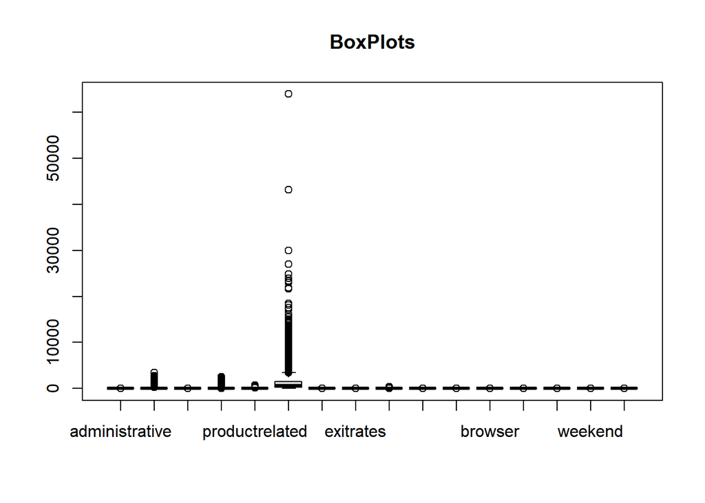

```r
# check for outliers/anomalies

# Finding all columns that are numerical/not strings & subsetting to new dataframe
df_num <- df[, !sapply(df, is.character)]
# ad_num <- subset(ad_num,select = -c(male, clicked_on_ad, area_income))
boxplot(df_num, main='BoxPlots')
```

> There are outliers in all the numerical columns.for now, no outliers are to be dropped

## Exploratory Data Analysis

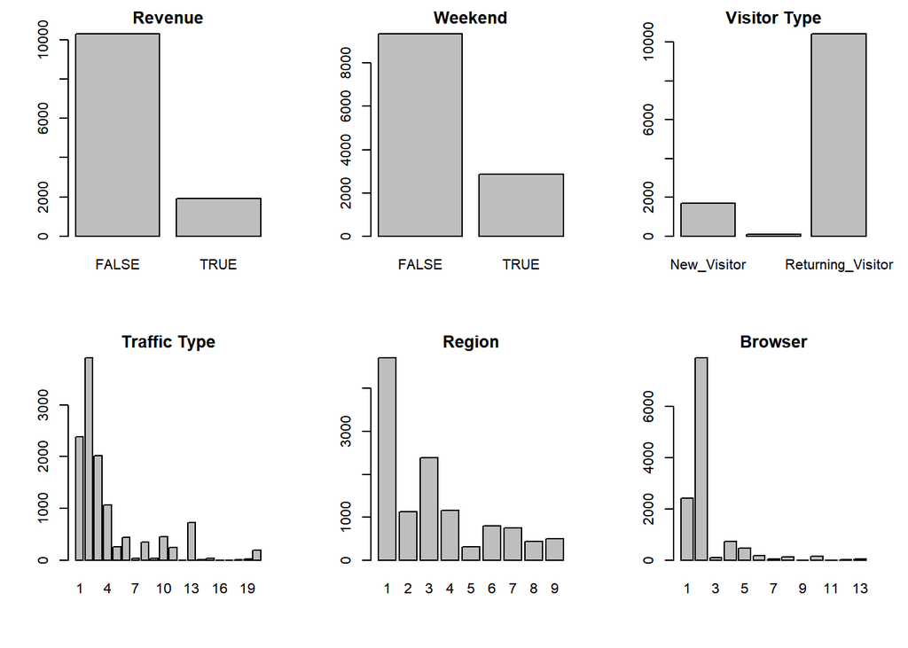

```r
# plotting barplots on the categorical columns
par(mfrow = c(2,3), mar = c(5,4,2,2))
barplot(table(df$revenue),main = "Revenue")
barplot(table(df$weekend),main = "Weekend")
barplot(table(df$visitortype),main = "Visitor Type")
barplot(table(df$traffictype),main = "Traffic Type")
barplot(table(df$region),main = "Region")
barplot(table(df$browser),main = "Browser")
```

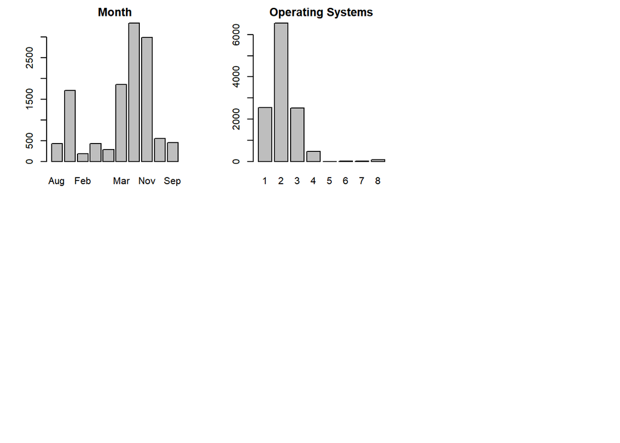

```r
barplot(table(df$month),main = "Month")
barplot(table(df$operatingsystems),main = "Operating Systems")
```

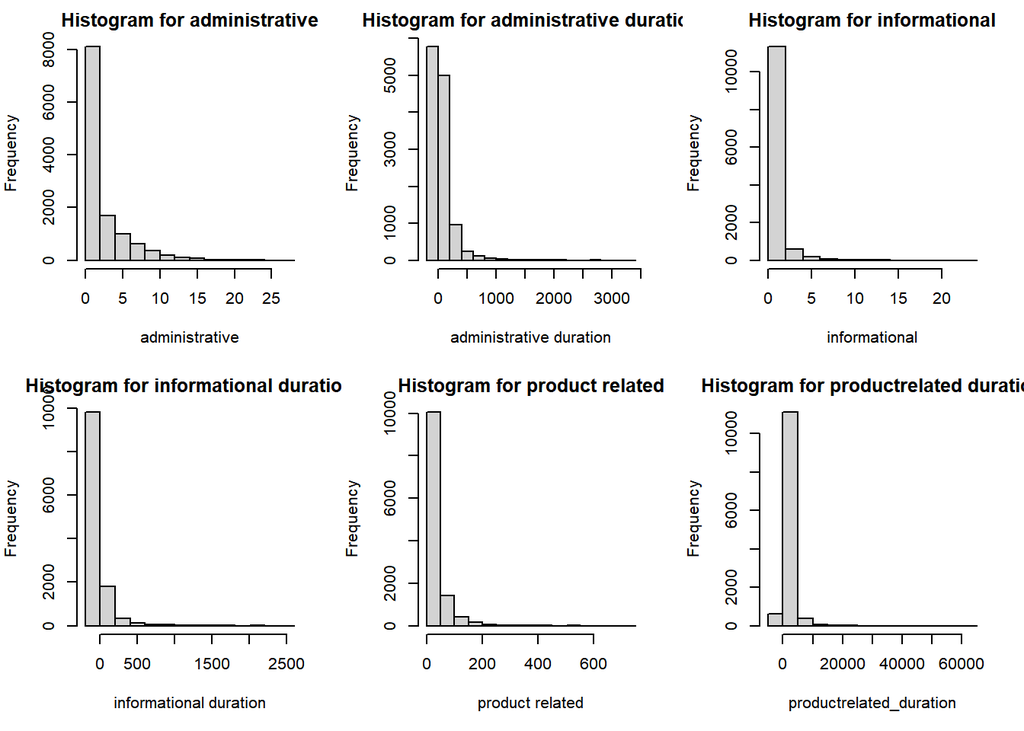

```r
# plotting histograms of the continuous variables
par(mfrow = c(2,3), mar = c(5,4,2,2))
hist(df$administrative,xlab ='administrative', main ='Histogram for administrative')
hist(df$administrative_duration,xlab ='administrative duration', main ='Histogram for administrative duration')
hist(df$informational,xlab ='informational', main ='Histogram for informational')
hist(df$informational_duration,xlab ='informational duration', main ='Histogram for informational duration')
hist(df$productrelated,xlab ='product related', main ='Histogram for product related')
hist(df$productrelated_duration,xlab ='productrelated_duration', main ='Histogram for productrelated duration')
```

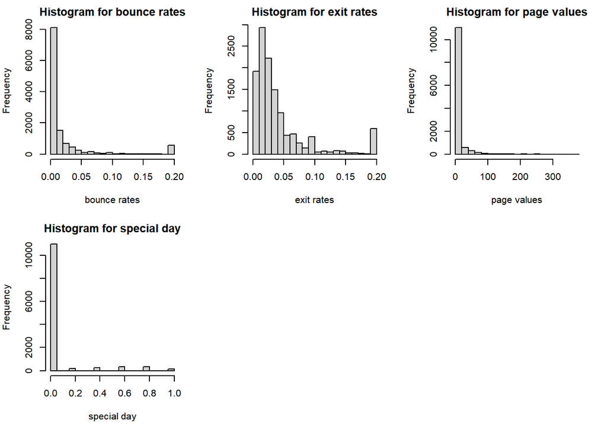

```r
hist(df$bouncerates,xlab ='bounce rates', main ='Histogram for bounce rates')
hist(df$exitrates,xlab ='exit rates', main ='Histogram for exit rates')
hist(df$pagevalues,xlab ='page values', main ='Histogram for page values')
hist(df$specialday,xlab ='special day', main ='Histogram for special day')
```

> Distribution for all the numerical columns is not Gaussian  
Most exit rates are between 0 and 0.05  
The administartive duration between 0 and 400 has a significant number of online profiles

```r
library(psych)
desc <- describe(df)
desc
```

```
##                         vars     n    mean      sd median trimmed    mad min
## administrative             1 12199    2.34    3.33   1.00    1.66   1.48   0
## administrative_duration    2 12199   81.68  177.53   9.00   42.87  13.34  -1
## informational              3 12199    0.51    1.28   0.00    0.18   0.00   0
## informational_duration     4 12199   34.84  141.46   0.00    3.73   0.00  -1
## productrelated             5 12199   32.06   44.60  18.00   23.06  19.27   0
## productrelated_duration    6 12199 1207.51 1919.93 609.54  832.36 745.12  -1
## bouncerates                7 12199    0.02    0.05   0.00    0.01   0.00   0
## exitrates                  8 12199    0.04    0.05   0.03    0.03   0.02   0
## pagevalues                 9 12199    5.95   18.66   0.00    1.33   0.00   0
## specialday                10 12199    0.06    0.20   0.00    0.00   0.00   0
## month*                    11 12199    6.17    2.37   7.00    6.36   1.48   1
## operatingsystems          12 12199    2.12    0.91   2.00    2.06   0.00   1
## browser                   13 12199    2.36    1.71   2.00    2.00   0.00   1
## region                    14 12199    3.15    2.40   3.00    2.79   2.97   1
## traffictype               15 12199    4.07    4.02   2.00    3.22   1.48   1
## visitortype*              16 12199    2.72    0.69   3.00    2.89   0.00   1
## weekend                   17 12199     NaN      NA     NA     NaN     NA Inf
## revenue                   18 12199     NaN      NA     NA     NaN     NA Inf
##                              max    range  skew kurtosis    se
## administrative             27.00    27.00  1.95     4.63  0.03
## administrative_duration  3398.75  3399.75  5.59    50.09  1.61
## informational              24.00    24.00  4.01    26.64  0.01
## informational_duration   2549.38  2550.38  7.54    75.45  1.28
## productrelated            705.00   705.00  4.33    31.04  0.40
## productrelated_duration 63973.52 63974.52  7.25   136.57 17.38
## bouncerates                 0.20     0.20  3.15     9.25  0.00
## exitrates                   0.20     0.20  2.23     4.62  0.00
## pagevalues                361.76   361.76  6.35    64.93  0.17
## specialday                  1.00     1.00  3.28     9.78  0.00
## month*                     10.00     9.00 -0.83    -0.37  0.02
## operatingsystems            8.00     7.00  2.03    10.27  0.01
## browser                    13.00    12.00  3.22    12.53  0.02
## region                      9.00     8.00  0.98    -0.16  0.02
## traffictype                20.00    19.00  1.96     3.47  0.04
## visitortype*                3.00     2.00 -2.05     2.23  0.01
## weekend                     -Inf     -Inf    NA       NA    NA
## revenue                     -Inf     -Inf    NA       NA    NA
```

the above output shows the distributions the various variables

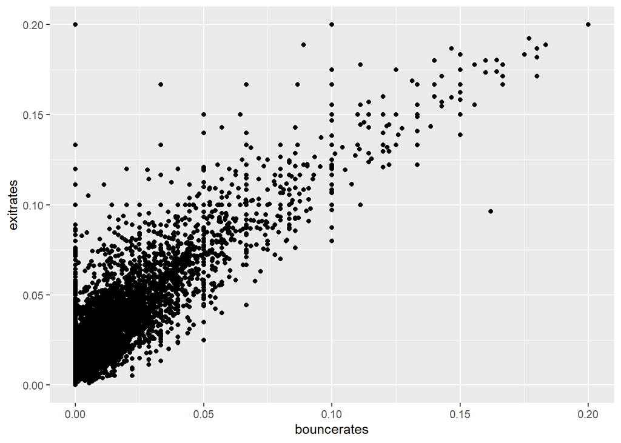

```r
library(ggplot2)
# Basic scatter plot without handling outliers
ggplot(df, aes(x=bouncerates, y=exitrates)) + geom_point()
```

> exitrates and bounce rates shows a positove corrlation

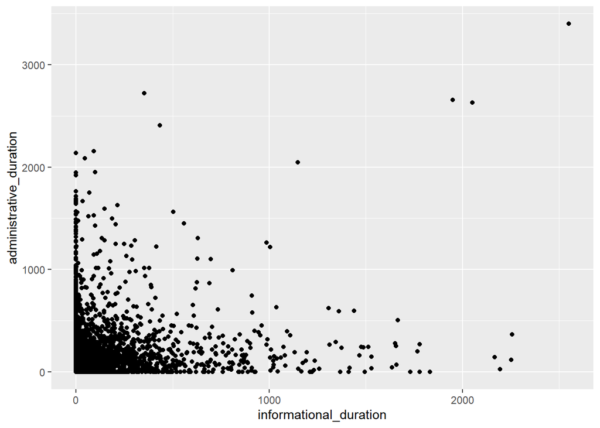

```r
# Basic scatter plot without handling outliers
ggplot(df, aes(x=informational_duration, y=administrative_duration)) +
geom_point()
```

> the length of duration seems to cluster between 0 and 500

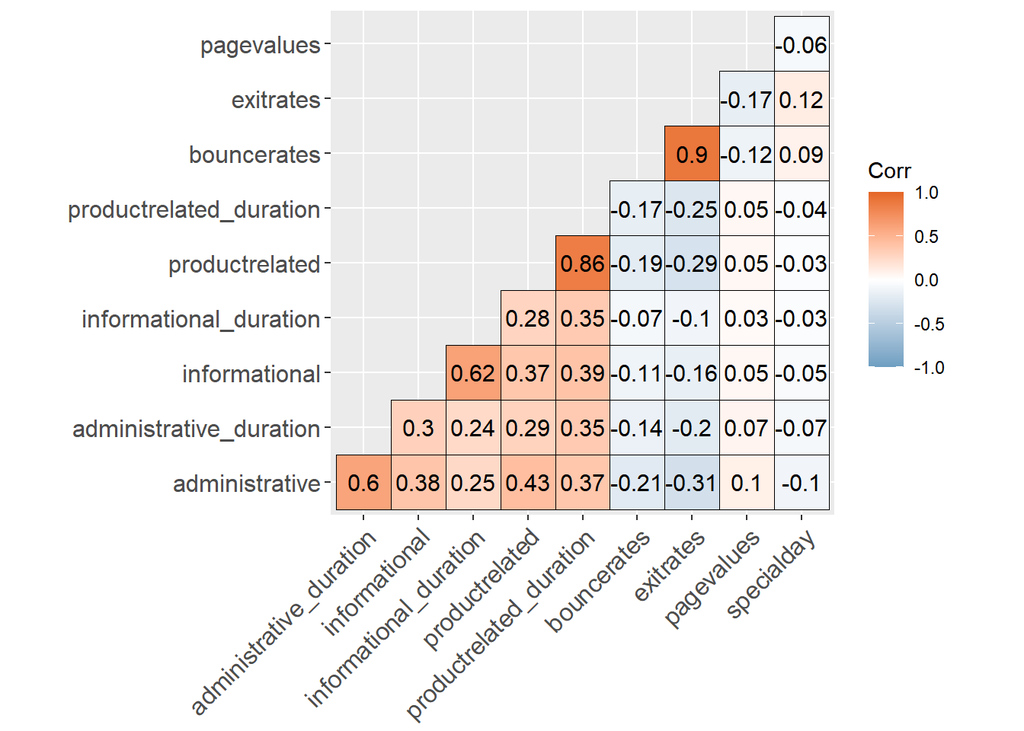

```r
library(ggcorrplot)
ggcorrplot(cor(df[ , c(1:10)]), type = "lower", outline.col = "black",
 lab=TRUE,
 ggtheme = ggplot2::theme_gray,
 colors = c("#6D9EC1", "white", "#E46726"))
```

> variables with high positive correlataion:  
* exitrates & bouncerates * productrelated & produtrelated_duration * informational & informational_duration * administrative & administartive_duration

## Implementing The Solution

### Data preparation

```r
# dropping the characterised variables
df.new<-df[ ,c(1:10,12:15)]
```

```r
# normalizing the data
normalize <- function(x){
  return ((x-min(x)) / (max(x)-min(x)))
}

df.norm <- normalize (df.new)
```

```r
# this step was added because finding the optimum number of clusters took sometime. therefore taking a random sample of 1500
rand_df <- df.norm[sample(nrow(df.norm), size=1500), ]
head(rand_df)
```

```
##       administrative administrative_duration informational
## 2008    1.563122e-05            1.563122e-05  1.563122e-05
## 9681    1.563122e-05            1.563122e-05  1.563122e-05
## 10118   9.378734e-05            3.149691e-03  4.689367e-05
## 2235    9.378734e-05            1.094186e-03  7.815611e-05
## 4621    1.563122e-05            1.563122e-05  1.563122e-05
## 11227   6.252489e-05            6.408801e-04  1.563122e-05
##       informational_duration productrelated productrelated_duration
## 2008            1.563122e-05   4.689367e-05            0.0002500996
## 9681            1.563122e-05   1.094186e-04            0.0074300412
## 10118           6.111808e-03   5.158303e-04            0.0141551142
## 2235            2.563521e-03   7.971924e-04            0.0379174383
## 4621            1.563122e-05   2.032059e-04            0.0054709279
## 11227           1.563122e-05   3.907806e-04            0.0598832139
##        bouncerates    exitrates   pagevalues   specialday operatingsystems
## 2008  1.563122e-05 1.719434e-05 1.563122e-05 1.563122e-05     3.126245e-05
## 9681  1.563122e-05 1.578753e-05 1.563122e-05 1.563122e-05     3.126245e-05
## 10118 1.577204e-05 1.602834e-05 1.563122e-05 1.563122e-05     3.126245e-05
## 2235  1.563122e-05 1.599595e-05 6.210620e-05 1.563122e-05     4.689367e-05
## 4621  1.667330e-05 1.702066e-05 1.563122e-05 1.563122e-05     4.689367e-05
## 11227 1.563122e-05 1.602721e-05 1.563122e-05 1.563122e-05     3.126245e-05
##            browser       region  traffictype
## 2008  3.126245e-05 3.126245e-05 4.689367e-05
## 9681  3.126245e-05 6.252489e-05 6.252489e-05
## 10118 4.689367e-05 3.126245e-05 4.689367e-05
## 2235  4.689367e-05 6.252489e-05 6.252489e-05
## 4621  4.689367e-05 1.563122e-04 2.188371e-04
## 11227 3.126245e-05 1.250498e-04 1.406810e-04
```

### K means Clustering

```r
# Loading the required libraries
library(factoextra)
library(NbClust)
library (cluster)
```

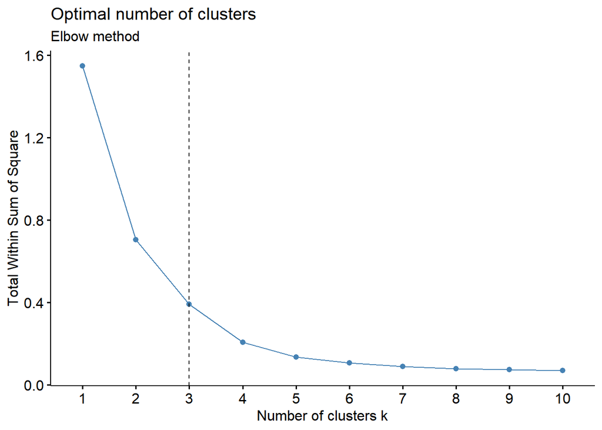

```r
# Elbow method
fviz_nbclust(rand_df, kmeans, method = "wss") +
    geom_vline(xintercept = 3, linetype = 2)+
  labs(subtitle = "Elbow method")
```

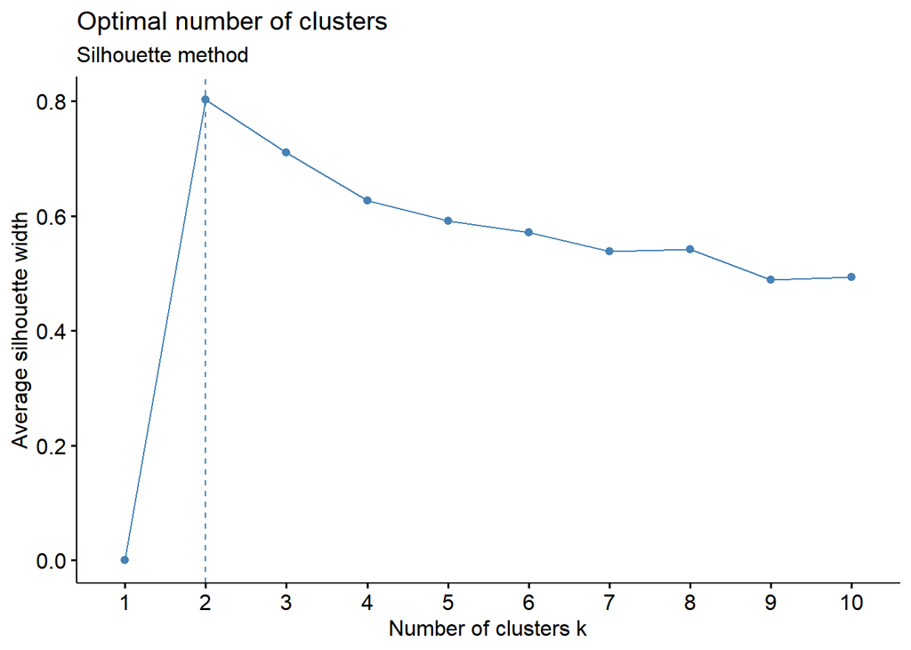

```r
# Silhouette method
fviz_nbclust(rand_df, kmeans, method = "silhouette")+
  labs(subtitle = "Silhouette method")
```

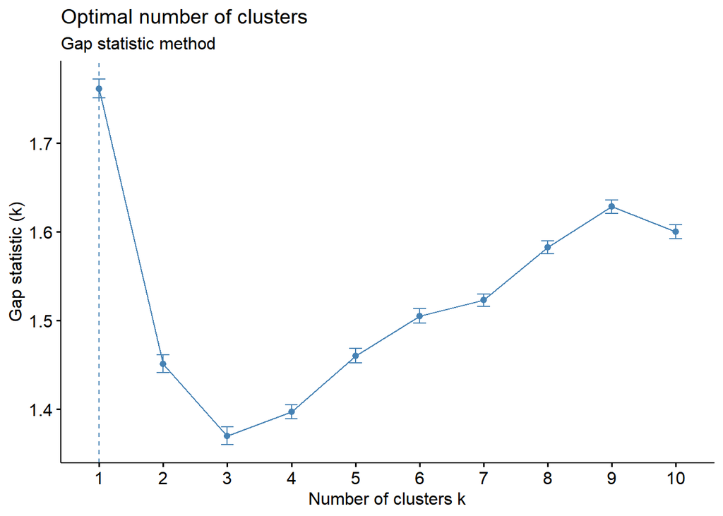

```r
# Gap statistic
# nboot = 50 to keep the function speedy.

set.seed(123)
fviz_nbclust(rand_df, kmeans, nstart = 25,  method = "gap_stat", nboot = 50)+
  labs(subtitle = "Gap statistic method")
```

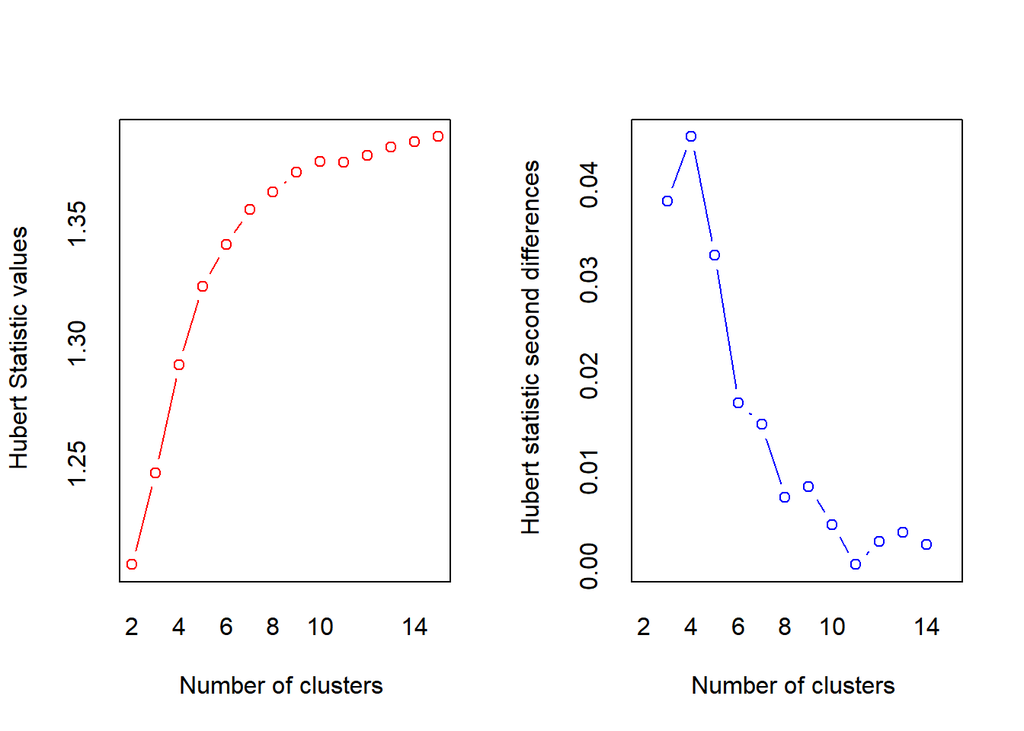

```
## *** : The Hubert index is a graphical method of determining the number of clusters.
##                 In the plot of Hubert index, we seek a significant knee that corresponds to a
##                 significant increase of the value of the measure i.e the significant peak in Hubert
##                 index second differences plot.
##
```

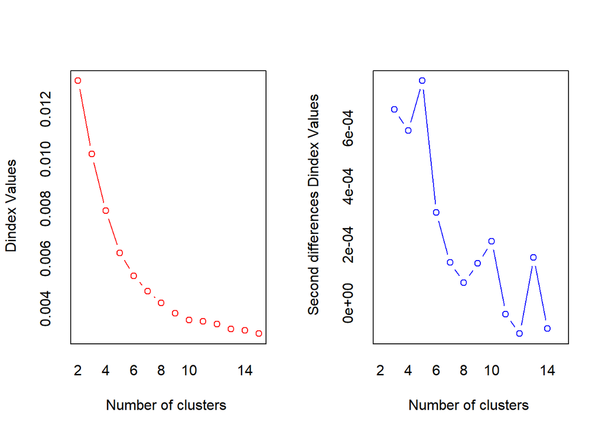

```
## *** : The D index is a graphical method of determining the number of clusters.
##                 In the plot of D index, we seek a significant knee (the significant peak in Dindex
##                 second differences plot) that corresponds to a significant increase of the value of
##                 the measure.
##
## * Among all indices:
## * 5 proposed 2 as the best number of clusters
## * 4 proposed 3 as the best number of clusters
## * 5 proposed 4 as the best number of clusters
## * 1 proposed 5 as the best number of clusters
## * 1 proposed 6 as the best number of clusters
## * 2 proposed 8 as the best number of clusters
## * 1 proposed 9 as the best number of clusters
## * 1 proposed 12 as the best number of clusters
## * 2 proposed 13 as the best number of clusters
## * 1 proposed 14 as the best number of clusters
## * 1 proposed 15 as the best number of clusters
##
##                    ***** Conclusion *****
##
## * According to the majority rule, the best number of clusters is  2
##
##
```

```r
# choosing the best number of clusters
nb<-NbClust(data = rand_df, distance = "euclidean",
        min.nc = 2, max.nc = 15, method = "kmeans")
```